# Visualizing FordGo Bike Dataset

## Investigation Overview

- Here we investigate FordGo Bike Dataset, We will try find relationship between features of this dataset and look at the behaviors and characteristic on user_type, start_time, gender and age.

## Dataset Overview

- This data set includes information about individual rides made in a bike-sharing system covering the greater San Francisco Bay area. Ford GoBike is the Bay Area's bike share system. Bay Area Bike Share was introduced in 2013 as a pilot program for the region, with 700 bikes and 70 stations across San Francisco and San Jose. Once expansion is complete, Ford GoBike will grow to 7,000 bikes across San Francisco, the East Bay and San Jose.
- Ford GoBike, like other bike share systems, consists of a fleet of specially designed, sturdy and durable bikes that are locked into a network of docking stations throughout the city. The bikes can be unlocked from one station and returned to any other station in the system, making them ideal for one-way trips. People use bike share to commute to work or school, run errands, get to appointments or social engagements and more. It's a fun, convenient and affordable way to get around.
- The bikes are available for use 24 hours/day, 7 days/week, 365 days/year and riders have access to all bikes in the network when they become a member or purchase a pass.

[figure not shown]

```python
from IPython.display import Image
Image('ford_gobike.jpg')
```

### FordGo Monthwise(7-month) usage

- In this seven months highest peak is october which is early-mid autumn with highest popualarity to use Ford go. with second as September and November together.
- San Francisco is best in the mid-late summer as it usually stays sunny until returning to its usual foggy weather in the late autumn/early winter months.
- And temperature aint that hot compare to summer

```python
# statistic of month
df['start_time_month'].value_counts()
```

```
October      95316
November     86090
September    85437
December     78236
August       69783
July         35910
June          2387
Name: start_time_month, dtype: int64
```

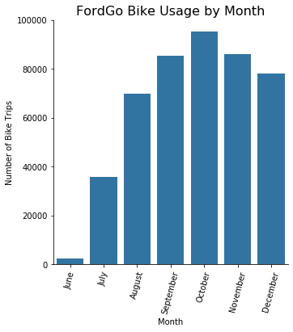

```python
# month list with the seven month
month = ['June','July','August','September','October','November','December']
# monthly usage of Fordgo bike
base_col = sns.color_palette()[0]
g = sns.catplot(data = df, x = 'start_time_month', kind = 'count', color = base_col, order=month);
g.set_axis_labels('Month', 'Number of Bike Trips'),
g.set_xticklabels(rotation=75);
plt.title('FordGo Bike Usage by Month', fontsize=16);
```

### FordGo day wise usage in week

- Since this data is from the bay area and there mainly office people there so it likely that there won't be less i users in weekends then any other days.

```python
# statistic of month
df['start_time_days'].value_counts()
```

```
Tue    80482
Wed    80357
Thu    77198
Mon    73536
Fri    72018
Sat    36780
Sun    32788
Name: start_time_days, dtype: int64
```

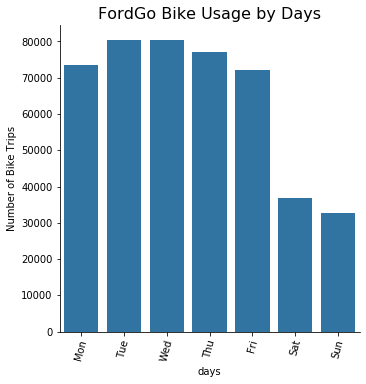

```python
# day wise usage distribution
days = ['Mon', 'Tue', 'Wed', 'Thu', 'Fri', 'Sat', 'Sun']

g = sns.catplot(data=df, x='start_time_days', kind='count', color = base_col, order = days)
g.set_axis_labels('days', 'Number of Bike Trips')
g.set_xticklabels(rotation=75)
plt.title('FordGo Bike Usage by Days', fontsize=16);
```

### FordGo dirtibution in a day(hour wise)

- From the observation we can say that most office work starts at 8-9 am and ends in 5-6 pm so there is highest peak in this two time or students who mostly have their classes from 9am and ends at 5 pm.

```python
# statistic
df['distance_km'].describe()
```

[output not shown]

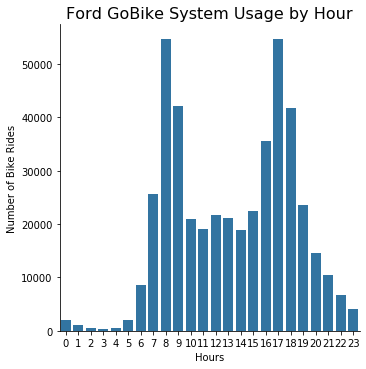

```python
# Hour wise usage
ax = sns.catplot(data = df, x='start_time_hour', kind='count', color = base_col)
ax.set_axis_labels('Hours', 'Number of Bike Rides')
plt.title('Ford GoBike System Usage by Hour', fontsize=16);
```

### Ford Gobike Trip ddistance in KM

- 75% of total distance is 2.07 km
- average of bike trip distance is 1.6 km

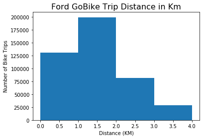

```python
# Distance in km traveled
bin_e = np.arange(0, 5, 1)

plt.hist(data = df, x = 'distance_km', bins = bin_e);

plt.title("Ford GoBike Trip Distance in Km", fontsize=16)
plt.xlabel('Distance (KM)')
plt.ylabel('Number of Bike Trips');
```

## Gender Outlook

```python
df.groupby('member_gender')[['duration_min','distance_km']].describe()
```

| member_gender | duration_min count | duration_min mean | duration_min std | duration_min min | duration_min 25% | duration_min 50% | duration_min 75% | duration_min max | distance_km count | distance_km mean | distance_km std | distance_km min | distance_km 25% | distance_km 50% | distance_km 75% | distance_km max |
| --- | --- | --- | --- | --- | --- | --- | --- | --- | --- | --- | --- | --- | --- | --- | --- | --- |
| Female | 98542.0 | 16.639413 | 52.797884 | 1.0 | 6.0 | 10.0 | 16.0 | 1437.0 | 98542.0 | 1.665789 | 1.017822 | 0.0 | 0.948092 | 1.452355 | 2.171534 | 17.114085 |
| Male | 348318.0 | 12.415792 | 38.135017 | 1.0 | 5.0 | 8.0 | 13.0 | 1432.0 | 348318.0 | 1.580477 | 0.969098 | 0.0 | 0.916543 | 1.397254 | 2.046541 | 62.293682 |
| Other | 6299.0 | 16.498968 | 56.482284 | 1.0 | 6.0 | 9.0 | 16.0 | 1376.0 | 6299.0 | 1.602564 | 1.168055 | 0.0 | 0.834024 | 1.339155 | 2.044374 | 9.023914 |

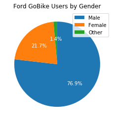

```python
plt.pie(gender, labels = gender.index, startangle = 90, autopct= '%1.1f%%', counterclock = False, textprops={'color':'white'});
plt.legend()
plt.title('Ford GoBike Users by Gender');
```

## Subscribers vs Customers

- 90% of user_type in this dataset are Subscribers and 10% customers

```python
# user_type
df['user_type'].value_counts()
```

```
Subscriber    404424
Customer       48735
Name: user_type, dtype: int64
```

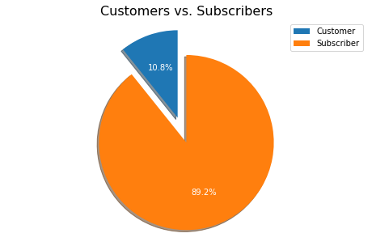

```python
# Pie chart customer and subscriber
plt.figure(figsize = [8, 5])

labels = ['Customer', 'Subscriber']
size = [customer_prop, subscriber_prop]
explode = (0, 0.3)

plt.pie(size, explode=explode, labels = labels, autopct='%1.1f%%', shadow=True, startangle=90, textprops={'color':'white'})
plt.axis('equal')
plt.legend()
plt.title('Customers vs. Subscribers', fontsize=16);
```

## Subscribers vs Customers - weekday usage

```python
df.groupby('user_type')['distance_km'].describe()
```

| user_type | count | mean | std | min | 25% | 50% | 75% | max |
| --- | --- | --- | --- | --- | --- | --- | --- | --- |
| Customer | 48735.0 | 1.795569 | 1.151823 | 0.0 | 1.024685 | 1.598571 | 2.403015 | 17.285075 |
| Subscriber | 404424.0 | 1.575688 | 0.958562 | 0.0 | 0.912433 | 1.387892 | 2.035262 | 62.293682 |

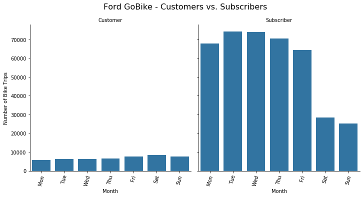

```python
# Customer Usage by daywise vs. Subscriber Usage by daywise

g = sns.catplot(data=df, x='start_time_days', col="user_type", kind='count', order = days, sharey = True, color = base_col);

g.set_axis_labels("Month", "Number of Bike Trips");
g.set_titles("{col_name}");

g.fig.suptitle('Ford GoBike - Customers vs. Subscribers', y=1.05, fontsize=16);
g.set_xticklabels(rotation=75);
```

## Subscribers vs Customers - Trip Duration minutes-wise usage

- average distance of customer is slightly higher then subscriber
- since customer tends to ride more distance so more time too
- customer of average rides more then 75% of subscriber

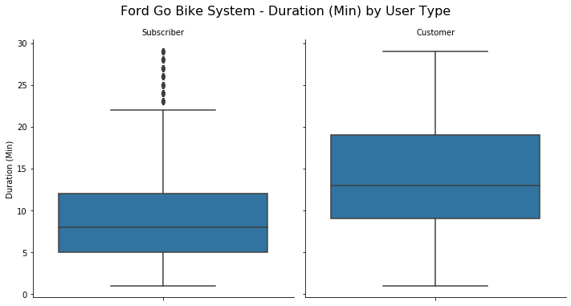

```python
#customer vs subscriber boxplot
data = df.query('duration_min < 30')

g = sns.catplot(data=data, y='duration_min', col="user_type", kind='box', color = base_col)

g.set_titles(col_template = '{col_name}')
g.set_axis_labels("", "Duration (Min)")
g.fig.suptitle('Ford Go Bike System - Duration (Min) by User Type', y=1.05, fontsize=16);
```

## Subscriber - Seven-Month Bike Trips Per Subscriber Age Group

- Subscriber of age group of 26-35 years old are the most common age group to use the bike sharing system.
- Age group of 26-35 years spike in month of October end-summer.
- The youngest age group, the 15-25 years olds starts off with very few rides.

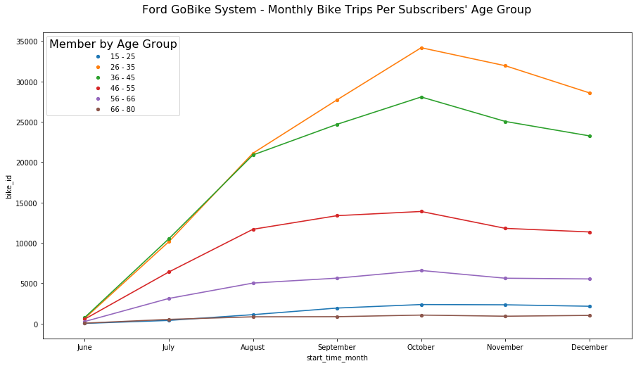

```python
# Comparing monthly number of bike trips per subscribers, on age group
import matplotlib.pyplot as plt
plt.figure(figsize = (15,8))

months = ['June', 'July', 'August', 'September', 'October', 'November', 'December']

ax = sns.pointplot(data = subscriber_age_df, x='start_time_month', y='bike_id', hue='age_bins', scale=.6, order = months, height=5, aspect=2);

ax.set_title("Ford GoBike System - Monthly Bike Trips Per Subscribers' Age Group", y = 1.05, fontsize = 16);
# Legend
leg = ax.legend()
leg.set_title('Member by Age Group', prop={'size': 16})
```

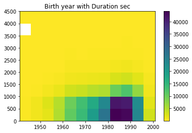

```python
# Relation of birth year with duration sec
xbin = np.arange(1941, df['member_birth_year'].max()+5, 5)
ybin = np.arange(0, 4039.5+500, 500)
plt.hist2d(data = df,x = 'member_birth_year',y='duration_sec',cmin=0.5,cmap = 'viridis_r',bins=[xbin, ybin]);
plt.colorbar()
plt.title('Birth year with Duration sec');
```

- there is high concentration young people(1980-2000) that have a travel duration between 0-1250~s

## Subscribers vs Customers on Week of Day and Day of Hour

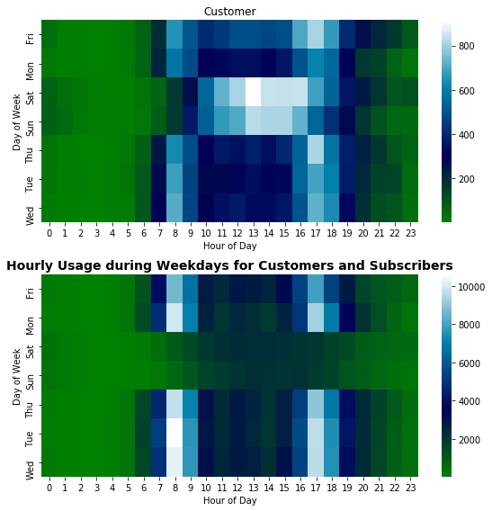

```python
# Figure
plt.figure(figsize=[8, 8]);
# first subplot
plt.subplot(2, 1, 1)
customers = df.query('user_type == "Customer"')
customers_df = customers.groupby(['start_time_days', 'start_time_hour']).size()
customers_df = customers_df.reset_index(name='count')
customers_df = customers_df.pivot(index='start_time_days', columns='start_time_hour', values='count')
sns.heatmap(customers_df, cmap='ocean');
plt.title('Customer', loc='center');
plt.xlabel('Hour of Day');
plt.ylabel('Day of Week');
plt.tight_layout();
# second subplot
plt.subplot(2, 1, 2)
subscribers = df.query('user_type == "Subscriber"')
subscriber_df = subscribers.groupby(['start_time_days', 'start_time_hour']).size()
subscriber_df = subscriber_df.reset_index(name='count')
subscriber_df = subscriber_df.pivot(index='start_time_days', columns='start_time_hour', values='count')
sns.heatmap(subscriber_df, cmap='ocean');
plt.title('Subscriber', loc='center');
plt.xlabel('Hour of Day');
plt.ylabel('Day of Week');
plt.tight_layout();
plt.title('Hourly Usage during Weekdays for Customers and Subscribers', fontsize=14, fontweight='semibold', y=1.015);
```

## Summary

From the plot Subscribers that are aged in group between 26-35 years old are the most common age group to use the bike sharing system. The 26-35 years old also tends lead the spike which occurs across all age groups in October As these age are the working age. Subscribers who fall in the 36-45 year old age group are the next most common age group to use the bike sharing system, and follow a similar trend at the 26-35 year olds.

```python
!jupyter nbconvert slides_deck1.ipynb --to slides --template output-toggle.tpl --post serve
```

[output not shown]

[output cut: 75 more lines]

[output not shown]